# Foundations of Molecular Bonding

Author

Daniel Fischer

# Introduction

Before exploring molecular orbitals, spectroscopy, and quantitative models, it is useful to develop a **qualitative understanding of chemical bonding**. Why do atoms stick together? How does the potential energy depend on the distance between nuclei? Which types of bonds exist, and what are their characteristic energies and lengths?

In this chapter, we will explore:

- The **origin of chemical bonds** from electronic interactions
- **Potential energy curves** and their relation to molecular stability
- The main **types of chemical bonds**: covalent, ionic, and van der Waals
- A **first look at molecular orbitals** and bonding/antibonding concepts

This foundation provides the conceptual framework for the more quantitative treatments in later chapters, including H$_2^+$, LCAO, and molecular spectroscopy.

# 1. Formation of Molecular Bonds and Potential Energy Curves

Molecules form because the **total energy of a system of atoms decreases** when they approach each other to a suitable distance. The total energy contains several competing contributions:

1. **Electron–nucleus attractions** — lower the energy and favor bonding
2. **Electron–electron repulsions** — increase the energy
3. **Nucleus–nucleus repulsions** — increase the energy
4. **Electron kinetic energy** — increases with spatial confinement (Heisenberg uncertainty principle)

The balance of these effects determines whether the overall energy decreases upon approach.

## 1.1 Potential Energy Curves

To describe how the total energy changes with the **internuclear distance** $R$, we define a **potential energy curve** — the energy of the molecule as a function of $R$.

- At **large $R$**, the atoms are essentially independent; the energy approaches the **dissociation limit**.
- As the atoms move closer, **attraction between electrons and nuclei** dominates, and the total energy decreases.
- At some point, these attractive effects are balanced by **repulsive interactions** between overlapping electron clouds and the positively charged nuclei.
- The **minimum of the potential curve** marks the **equilibrium distance** $R_e$, where the molecule is most stable.

This characteristic shape — steeply repulsive at short distances, attractive at intermediate ones, and flat at large separations — explains why molecules exist with definite bond lengths and binding energies.

**NoteExample: Potential Energy Curves for Bonding and Antibonding States**

The figure below shows schematic potential energy curves for a diatomic molecule. The **bonding** configuration has a distinct energy minimum at the equilibrium distance $R_e$, while the **antibonding** configuration remains repulsive and asymptotically approaches the dissociation limit.

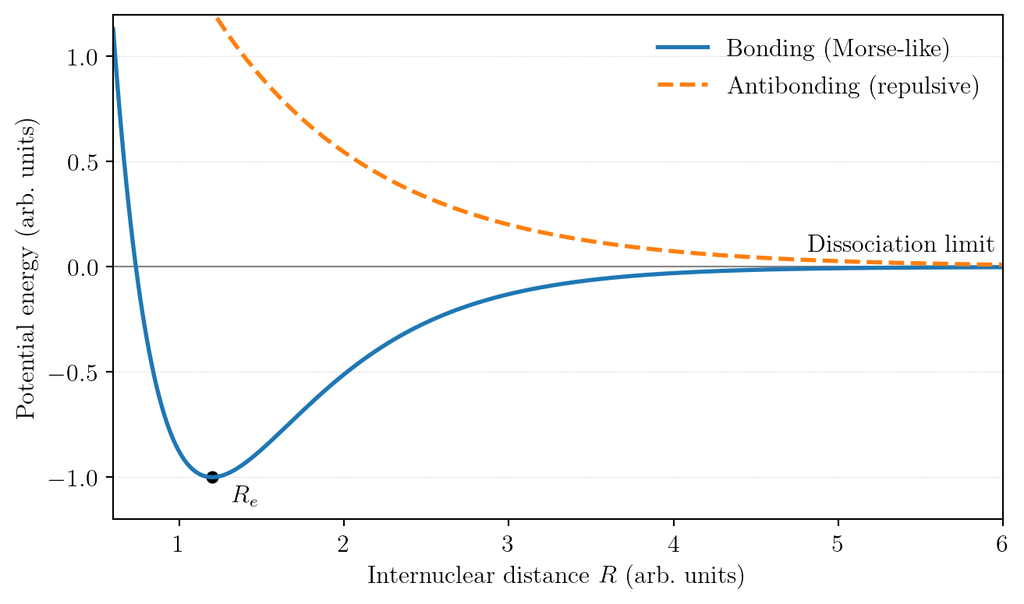

```python
import numpy as np
import matplotlib.pyplot as plt

plt.rcParams['text.usetex'] = True
plt.rcParams['font.family'] = 'serif'
plt.rcParams['font.size'] = 12

R = np.linspace(0.6, 6.0, 800)

# Bonding: shifted Morse potential (min = -D at R = Re, dissociation -> 0)
D = 1.0        # binding energy (arbitrary units)
a = 1.5        # width parameter
Re = 1.2       # equilibrium distance
V_bond = D*(1 - np.exp(-a*(R - Re)))**2 - D

# Antibonding: positive (repulsive) curve that -> 0 for large R
A = 0.9        # amplitude of short-range positive exponential
alpha = 1.0
R0 = 1.5
B = 0.05       # coefficient for steep short-range repulsion ~ 1/R^12
V_anti = A * np.exp(-alpha*(R - R0)) + B / R**12

fig, ax = plt.subplots(figsize=(7,4.2))

ax.plot(R, V_bond, label='Bonding (Morse-like)', linewidth=2)
ax.plot(R, V_anti, label='Antibonding (repulsive)', linestyle='--', linewidth=2)

# Dissociation limit (zero)
ax.axhline(0, color='gray', linewidth=0.8, zorder=-1)
ax.text(5.95, 0.05, 'Dissociation limit', va='bottom', ha='right') # , color='gray', fontsize=10)

# Mark equilibrium
R_eq = Re
V_eq = D*(1 - np.exp(-a*(R_eq - Re)))**2 - D  # = -D
ax.scatter([R_eq], [V_eq], color='black', s=25)
ax.text(R_eq + 0.12, V_eq - 0.12, r'$R_e$', fontsize=12)

# Labels and legend
ax.set_xlabel(r'Internuclear distance $R$ (arb.\ units)')
ax.set_ylabel('Potential energy (arb.\ units)')
# ax.set_title('Schematic Potential Energy Curves — Bonding vs. Antibonding')
ax.set_xlim(0.6, 6.0)
ax.set_ylim(-1.2, 1.2)
ax.legend(frameon=False)
ax.grid(axis='y', linestyle=':', linewidth=0.5, alpha=0.6)

plt.tight_layout()
plt.show()
```

## 1.2 The Concept of Molecular Orbitals

The shape of a potential energy curve can be understood in terms of how **atomic orbitals** from neighboring atoms combine to form **molecular orbitals**.

An **atomic orbital** describes the probability density of finding an electron around a single nucleus (for instance, the hydrogen 1s orbital). When two atoms come close, their orbitals overlap and combine to form new orbitals that extend over both nuclei. These are called **molecular orbitals**.

Two qualitatively different combinations are possible:

- **Bonding orbital:**  
  The wave functions of the two atoms add *constructively*, increasing the **electron density between the nuclei**. This enhances the attractive electron–nucleus interactions and lowers the total energy.
- **Antibonding orbital:**  
  The wave functions add *destructively*, creating a **node** (a region of zero electron density) between the nuclei. The resulting decrease in electron density in the bonding region and the increased confinement of the electron raise the total energy.

## 1.3 Why Bonding Lowers Energy

The stabilization of a bonding molecular orbital has two main origins:

1. **Potential energy reduction:**  
   More electron density between the nuclei means the negative electron charge more effectively screens the repulsion between positively charged nuclei.
2. **Kinetic energy reduction:**
   The bonding orbital is more spatially extended than the original atomic orbitals. Because of the Heisenberg uncertainty relation,
   $$\Delta x \, \Delta p \ge \frac{\hbar}{2},$$
   a larger spatial spread ($\Delta x$) implies a smaller momentum spread ($\Delta p$), and hence lower average kinetic energy.

Together, these effects explain why the **bonding molecular orbital** has **lower energy** and forms a stable bond, while the **antibonding orbital** leads to repulsion and dissociation.

## 1.4 Summary of the Qualitative Picture

| Feature | Bonding Orbital | Antibonding Orbital |
| --- | --- | --- |
| Wave function combination | Constructive | Destructive |
| Electron density between nuclei | High | Low (node) |
| Potential energy | Decreases | Increases |
| Kinetic energy | Decreases slightly | Increases |
| Overall effect | Stabilization → bond formation | Destabilization → repulsion |

This qualitative picture already captures the essential reason why **molecules exist**:  
under certain conditions, **sharing or redistributing electron density** allows the system to achieve a lower total energy than the separated atoms.

# 2. Different Types of Bonds

Molecular bonds can be classified based on **how electrons are distributed** and the **nature of the interaction**. In this section, we discuss covalent, ionic, and van der Waals bonds with qualitative explanations and visualizations.

## 2.1 Covalent Bond

A **covalent bond** forms when **atomic orbitals from two atoms overlap significantly**.

- Let $r_A$ and $r_B$ denote the **approximate sizes (radii of the atomic orbitals)** of atoms A and B.
- When the internuclear distance $R$ becomes smaller than $r_A + r_B$, orbitals overlap, and the energy drops due to the attraction of electrons to both nuclei.

Near the equilibrium distance $R_e$, the potential well can be approximated by a **harmonic shape**, while at larger distances, the energy approaches the dissociation limit $E_B$.

#### Morse Potential

A realistic model for covalent bonds is the Morse potential:

$$E_{\rm pot}(R) = E_B \left(1 - e^{-a(R-R_e)}\right)^2$$

- $E_B$ : depth of the potential well (binding energy)
- $R_e$ : equilibrium bond distance
- $a$ : controls width of the potential well

#### Visualization

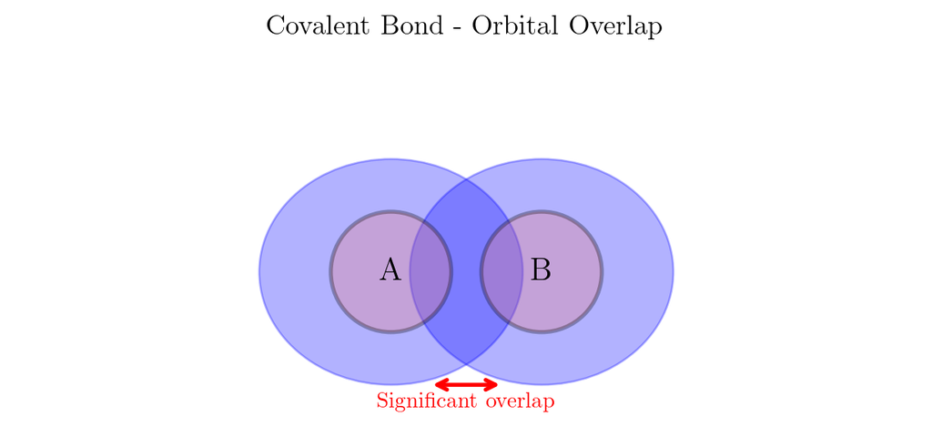

```python
import numpy as np
import matplotlib.pyplot as plt
from matplotlib.patches import Circle, Ellipse

plt.rcParams['text.usetex'] = True
plt.rcParams['font.family'] = 'serif'
plt.rcParams['font.size'] = 12

fig, ax = plt.subplots(figsize=(8, 4))

def draw_atom(ax, x, y, radius, label, color='lightblue'):
    circle = Circle((x, y), radius, fill=True, color=color, alpha=0.3, ec='black', lw=2)
    ax.add_patch(circle)
    ax.text(x, y, label, ha='center', va='center', fontsize=16, fontweight='bold')

def draw_density(ax, x, y, width, height, color='blue', alpha=0.2):
    ellipse = Ellipse((x, y), width, height, fill=True, color=color, alpha=alpha)
    ax.add_patch(ellipse)

draw_density(ax, 4, 0, 3.5, 3, 'blue', 0.3)
draw_density(ax, 6, 0, 3.5, 3, 'blue', 0.3)
draw_atom(ax, 4, 0, 0.8, 'A', 'lightcoral')
draw_atom(ax, 6, 0, 0.8, 'B', 'lightcoral')

ax.annotate('', xy=(5.5, -1.5), xytext=(4.5, -1.5),
            arrowprops=dict(arrowstyle='<->', color='red', lw=2))
ax.text(5, -1.8, 'Significant overlap', ha='center', fontsize=11, color='red')

ax.set_xlim(-1, 11)
ax.set_ylim(-2, 3)
ax.set_aspect('equal')
ax.axis('off')
ax.set_title('Covalent Bond - Orbital Overlap', fontsize=14, fontweight='bold')

plt.show()
```

## 2.2 Ionic Bond

Ionic bonds occur when one atom **transfers an electron** to another, forming a **cation and an anion**:

$$\text{NaI} : \quad \text{Na} + \text{I} \to \text{Na}^+ + \text{I}^-$$

In this case, the sodium atom loses an electron to become positively charged, while iodine gains an electron to become negatively charged. The resulting **electrostatic attraction** between the oppositely charged ions pulls them together, forming a bond.

- Unlike covalent bonds, the electron is **localized primarily on one atom**, rather than being shared equally.
- The **potential energy** falls off more slowly with distance than in covalent bonds, because the Coulomb attraction $\sim 1/R$ is long-range.
- Ionic bonds are **typically stronger than van der Waals bonds**, and their equilibrium distances are usually larger than covalent bond lengths for similar elements.
- Real ionic molecules often show some **covalent character**, especially if the atoms have similar electronegativities, but the dominant interaction is electrostatic.

#### Visualization

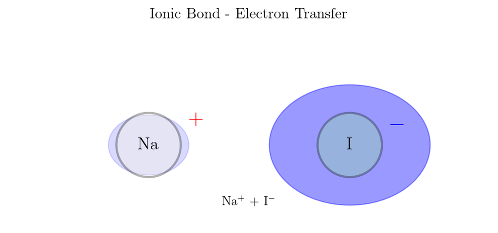

```python
fig, ax = plt.subplots(figsize=(8, 4))

draw_density(ax, 2.5, 0, 2, 1.5, 'blue', 0.15)
draw_density(ax, 7.5, 0, 4, 3, 'blue', 0.4)

draw_atom(ax, 2.5, 0, 0.8, 'Na', 'lightyellow')
draw_atom(ax, 7.5, 0, 0.8, 'I', 'lightgreen')

ax.text(3.5, 0.5, '+', fontsize=20, color='red', fontweight='bold')
ax.text(8.5, 0.5, '−', fontsize=20, color='blue', fontweight='bold')

ax.text(5, -1.5, 'Na$^+$ + I$^-$', ha='center', fontsize=12)

ax.set_xlim(-1, 11)
ax.set_ylim(-2, 3)
ax.set_aspect('equal')
ax.axis('off')
ax.set_title('Ionic Bond - Electron Transfer', fontsize=14, fontweight='bold')

plt.show()
```

## 2.3 Van der Waals Bond

Van der Waals bonds arise between **neutral atoms or molecules** due to **instantaneous or induced dipoles**. These are the **weakest type of bond**, but they play a crucial role in **condensed phases** such as liquids, solids, and biological molecules.

- Even when atoms are neutral, **fluctuations in electron density** can induce a temporary dipole in one atom, which then induces a dipole in a neighboring atom.
- This interaction leads to a **weak attractive force** that falls off as $1/R^6$ at large distances.
- At very short distances, **electron cloud overlap** produces a strong **repulsive interaction** ($\sim 1/R^{12}$), preventing atoms from collapsing into each other.
- The net effect is a **shallow potential well**, with a relatively large equilibrium separation and low binding energy compared to covalent or ionic bonds.

#### Lennard-Jones Potential

$$E_{\rm pot}(R) = \frac{a}{R^{12}} - \frac{b}{R^6}$$

- $R^{-12}$ term: short-range repulsion
- $R^{-6}$ term: long-range attraction

#### Visualization

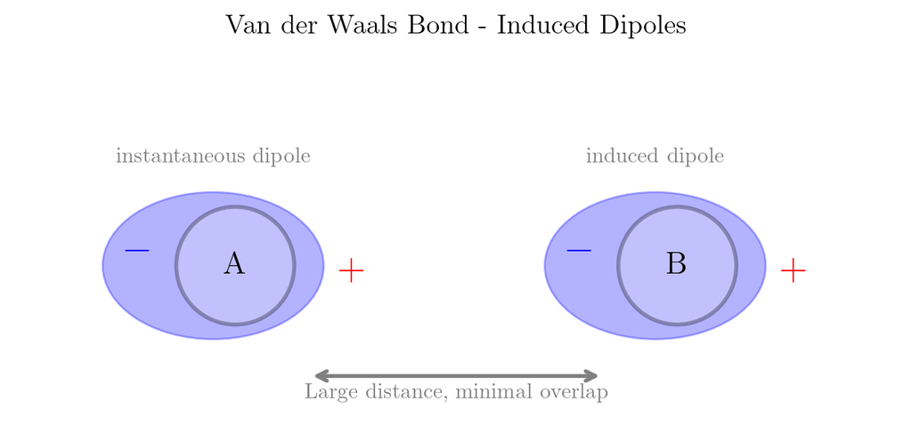

```python
fig, ax = plt.subplots(figsize=(8, 4))

draw_density(ax, 1.7, 0, 3, 2, 'blue', 0.3)
draw_density(ax, 7.7, 0, 3, 2, 'blue', 0.3)

draw_atom(ax, 2, 0, 0.8, 'A', 'lavender')
draw_atom(ax, 8, 0, 0.8, 'B', 'lavender')

ax.annotate('', xy=(7, -1.5), xytext=(3, -1.5),
            arrowprops=dict(arrowstyle='<->', color='gray', lw=2))
ax.text(5, -1.8, 'Large distance, minimal overlap', ha='center', fontsize=11, color='gray')
ax.text(1.7, 1.4, 'instantaneous dipole', ha='center', fontsize=11, color='gray')
ax.text(7.7, 1.4, 'induced dipole', ha='center', fontsize=11, color='gray')

ax.text(0.5, 0.2, '−', fontsize=20, color='blue', fontweight='bold')
ax.text(6.5, 0.2, '−', fontsize=20, color='blue', fontweight='bold')
ax.text(3.4, -0.2, '+', fontsize=20, color='red', fontweight='bold')
ax.text(9.4, -0.2, '+', fontsize=20, color='red', fontweight='bold')

ax.set_xlim(-1, 11)
ax.set_ylim(-2, 3)
ax.set_aspect('equal')
ax.axis('off')
ax.set_title('Van der Waals Bond - Induced Dipoles', fontsize=14, fontweight='bold')

plt.show()
```

Even though van der Waals bonds are weak, they are **ubiquitous**. They determine the properties of **noble gas solids**, **molecular crystals**, and contribute to **protein folding** and **molecular recognition** in biology.

# Summary

- **Bonds lower the total energy** by combining attractive and kinetic effects
- **Potential energy curves** define equilibrium distances and stability
- Three major bond types: **covalent, ionic, van der Waals**
- Early **molecular orbital concepts** explain bonding and antibonding behavior qualitatively

This qualitative foundation sets the stage for the **quantitative treatment** of molecules in subsequent chapters.